# Students who prefer face-to-face tests outperform their online peers in organic chemistry

Abby Beatty

5/23/2021

# Load all Necessary Packages

```r
library(reshape2)
library(nlme)
library(ggplot2)
library(plyr)
library(emmeans)
library(devtools)
library(tidyverse)
library(corrplot)
library(GPArotation)
library(semPlot)
library(lavaan)
library(cowplot)
library(readr)
library(tidyr)
library(Hmisc)
library(RColorBrewer)
library(PupillometryR)
library(car)
library(Rmisc)
library(psych)
library(janitor)
```

# Read in Survey data and Institutional Data

## Merge the two data files for use in analysis

```r
chem.cfa.raw=read.csv("CHEM_CFA.csv", header=T, na.strings = c("", "NA"))
chem.cfa.raw$GID<-toupper(chem.cfa.raw$GID)

institut=read.csv("Institutional_info.csv")

#Institutional data was then used to merge with survey data. Note: ACTcalc is raw ACT values when available, and SAT values converted to ACT when no ACT was reported but SAT was.
#Merge data using GID variable, which is present in both data sets.
chem.cfa <- merge(chem.cfa.raw,institut, by="GID", all=TRUE, incomparables = FALSE)
```

> Data is often scewed to the right. Only a couple of the data columns are normal. So data will need to be transformed. Go to this website to see alternitives to normalizing data within the cfa model: https://lavaan.ugent.be/tutorial/est.html “MLM”: maximum likelihood estimation with robust standard errors and a Satorra-Bentler scaled test statistic. For complete data only.See this pub for justification of test statistic choice: https://citeseerx.ist.psu.edu/viewdoc/download?doi=10.1.1.382.6856&rep=rep1&type=pdf

# CONFIRMATORY FACTOR ANALYSIS OF PREVIOUSLY VALIDATED CONSTRUCTS

> Really helpful youtube tutorial showing cfa function and semPlot: https://www.youtube.com/watch?v=KirEhSRSVI8

## CFA of Instrinsic Goal Orientation (written as grit in code) Measures

```r
#Intrinsic Goal Orientation

#Create model that contains all questions related to grit
(c1.model <- '
grit =~ G1 + G2 + G3 + G4 + G5')
```

```
## [1] "\ngrit =~ G1 + G2 + G3 + G4 + G5"
```

```r
#run confirmatory factor analysis on those questions using the MLM mode explained above
solution1 <- cfa(c1.model, data=chem.cfa, estimator= "MLM")

#Collect summary output, including all fitness measures based on the standardized outputs.
summary(solution1, fit.measures=T, standardized=TRUE)
```

```
## lavaan 0.6-8 ended normally after 32 iterations
##
##   Estimator                                         ML
##   Optimization method                           NLMINB
##   Number of model parameters                        10
##
##                                                   Used       Total
##   Number of observations                           198         307
##
## Model Test User Model:
##                                               Standard      Robust
##   Test Statistic                                20.952      16.534
##   Degrees of freedom                                 5           5
##   P-value (Chi-square)                           0.001       0.005
##   Scaling correction factor                                  1.267
##        Satorra-Bentler correction
##
## Model Test Baseline Model:
##
##   Test statistic                               198.815     134.274
##   Degrees of freedom                                10          10
##   P-value                                        0.000       0.000
##   Scaling correction factor                                  1.481
##
## User Model versus Baseline Model:
##
##   Comparative Fit Index (CFI)                    0.916       0.907
##   Tucker-Lewis Index (TLI)                       0.831       0.814
##
##   Robust Comparative Fit Index (CFI)                         0.921
##   Robust Tucker-Lewis Index (TLI)                            0.841
##
## Loglikelihood and Information Criteria:
##
##   Loglikelihood user model (H0)              -1690.345   -1690.345
##   Loglikelihood unrestricted model (H1)      -1679.869   -1679.869
##
##   Akaike (AIC)                                3400.690    3400.690
##   Bayesian (BIC)                              3433.573    3433.573
##   Sample-size adjusted Bayesian (BIC)         3401.893    3401.893
```

[output cut: 24 more lines]

```
##   grit =~
##     G1                1.000                               0.625    0.453
##     G2                1.589    0.316    5.020    0.000    0.993    0.564
##     G3                1.209    0.254    4.768    0.000    0.756    0.627
##     G4                1.840    0.385    4.782    0.000    1.150    0.798
##     G5                1.202    0.274    4.388    0.000    0.752    0.479
##
## Variances:
##                    Estimate  Std.Err  z-value  P(>|z|)   Std.lv  Std.all
##    .G1                1.512    0.161    9.388    0.000    1.512    0.795
##    .G2                2.121    0.244    8.705    0.000    2.121    0.682
##    .G3                0.880    0.151    5.818    0.000    0.880    0.606
##    .G4                0.755    0.157    4.811    0.000    0.755    0.363
##    .G5                1.899    0.201    9.443    0.000    1.899    0.771
##     grit              0.391    0.151    2.583    0.010    1.000    1.000
```

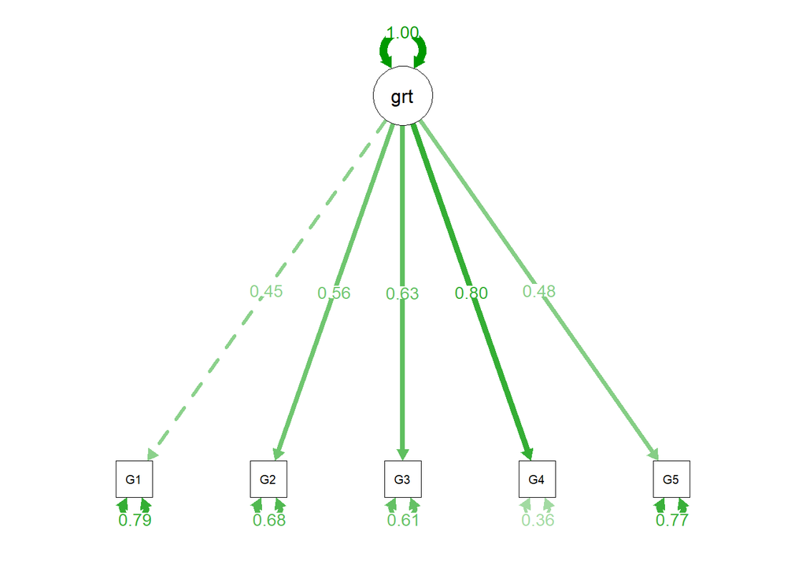

```r
#Produce SEM plot showing all estimates and standard deviations using the standardized values.
  #label and text sizes were increased from default 0.8 to 1.0
semPlot::semPaths(solution1, "std", edge.label.cex =1, label.cex=1)
```

```r
#Intrinsic Goal Orientation
(c1b.model <- '
grit =~ G2 + G3 + G4 + G5')
```

```
## [1] "\ngrit =~ G2 + G3 + G4 + G5"
```

```r
solution1b <- cfa(c1b.model, data=chem.cfa, estimator= "MLM")
summary(solution1b,fit.measures=T, standardized=TRUE)
```

```
## lavaan 0.6-8 ended normally after 27 iterations
##
##   Estimator                                         ML
##   Optimization method                           NLMINB
##   Number of model parameters                         8
##
##                                                   Used       Total
##   Number of observations                           198         307
##
## Model Test User Model:
##                                               Standard      Robust
##   Test Statistic                                 7.108       5.355
##   Degrees of freedom                                 2           2
##   P-value (Chi-square)                           0.029       0.069
##   Scaling correction factor                                  1.327
##        Satorra-Bentler correction
##
## Model Test Baseline Model:
##
##   Test statistic                               153.111     100.461
##   Degrees of freedom                                 6           6
##   P-value                                        0.000       0.000
##   Scaling correction factor                                  1.524
##
## User Model versus Baseline Model:
##
##   Comparative Fit Index (CFI)                    0.965       0.964
##   Tucker-Lewis Index (TLI)                       0.896       0.893
##
##   Robust Comparative Fit Index (CFI)                         0.969
##   Robust Tucker-Lewis Index (TLI)                            0.907
##
## Loglikelihood and Information Criteria:
##
##   Loglikelihood user model (H0)              -1361.636   -1361.636
##   Loglikelihood unrestricted model (H1)      -1358.082   -1358.082
##
##   Akaike (AIC)                                2739.272    2739.272
##   Bayesian (BIC)                              2765.578    2765.578
##   Sample-size adjusted Bayesian (BIC)         2740.234    2740.234
```

[output cut: 22 more lines]

```
## Latent Variables:
##                    Estimate  Std.Err  z-value  P(>|z|)   Std.lv  Std.all
##   grit =~
##     G2                1.000                               0.898    0.509
##     G3                0.827    0.159    5.195    0.000    0.743    0.616
##     G4                1.391    0.204    6.826    0.000    1.249    0.866
##     G5                0.783    0.160    4.906    0.000    0.703    0.448
##
## Variances:
##                    Estimate  Std.Err  z-value  P(>|z|)   Std.lv  Std.all
##    .G2                2.302    0.237    9.692    0.000    2.302    0.741
##    .G3                0.900    0.155    5.809    0.000    0.900    0.620
##    .G4                0.518    0.181    2.864    0.004    0.518    0.249
##    .G5                1.970    0.204    9.652    0.000    1.970    0.799
##     grit              0.806    0.224    3.595    0.000    1.000    1.000
```

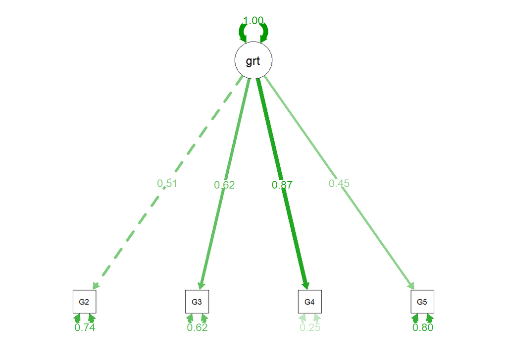

```r
semPlot::semPaths(solution1b, "std", edge.label.cex =1, label.cex=1)
```

```r
#Create index file of the factor scores collected from cfa. These will be adjust values to meet the loading determined for each survey question
idx <- lavInspect(solution1b, "case.idx")
fscores <- lavPredict(solution1b, type="lv")

## loop over factors and merge them with the original data set. All missing values will be input as "NA".
for (fs in colnames(fscores)) {
  chem.cfa[idx, fs] <- fscores[ , fs]
}

#preview the output to verify merge was successful
head(chem.cfa)
```

```
##       GID                 ID semester.x exam1 exam2 exam3 modeE1 modeE2 modeE3
## 1 AAP0049 aap0049@auburn.edu       Su20  75.0    80  62.0    f2f    f2f    f2f
## 2 AAR0036 aar0036@auburn.edu       Su20  89.5    71  72.5 online online online
## 3 AAT0038 aat0038@auburn.edu       Fa20  71.5    82  40.0    f2f    f2f    f2f
## 4 ABM0054 abm0054@auburn.edu       Fa20  91.0    82  86.0   <NA>   <NA>   <NA>
## 5 ABR0032 abr0032@auburn.edu       Su20  63.5    57  57.0 online online online
## 6 ABR0033 abr0033@auburn.edu       Fa20 105.0   114 102.0    f2f    f2f    f2f
##   G1 G2 T1 V1 V2 G3 V3 G4 G5 T2 V4 V5 T3 V6 T4 semester.y ACTHIGHEST SATHIGHEST
## 1 NA NA NA NA NA NA NA NA NA NA NA NA NA NA NA       Su20         32         NA
## 2 NA NA NA NA NA NA NA NA NA NA NA NA NA NA NA       Su20         22          0
## 3  3  5  7  6  3  5  3  4  6  7  5  3  7  4  7       Fa20         26         NA
## 4 NA NA NA NA NA NA NA NA NA NA NA NA NA NA NA       Fa20         28         NA
## 5 NA NA NA NA NA NA NA NA NA NA NA NA NA NA NA       Su20         30         NA
## 6  5  7  2  7  6  7  7  7  4  2  5  7  7  7  3       Fa20         34         NA
##   ACTcalc HS_GPA first_generation gender              race
```

[output cut: 20 more lines]

## CFA of Perceived Value of Chemistry (written as value in code) Measures

```r
#See code above for annotation details.

#Perceived Value of Chemistry
(c3.model <- '
values =~ V1 + V2 + V3 + V4 + V5 + V6')
```

```
## [1] "\nvalues =~ V1 + V2 + V3 + V4 + V5 + V6"
```

```r
solution3 <- cfa(c3.model, data=chem.cfa, estimator= "MLM")
summary(solution3,fit.measures=T, standardized=TRUE)
```

```
## lavaan 0.6-8 ended normally after 22 iterations
##
##   Estimator                                         ML
##   Optimization method                           NLMINB
##   Number of model parameters                        12
##
##                                                   Used       Total
##   Number of observations                           198         307
##
## Model Test User Model:
##                                               Standard      Robust
##   Test Statistic                                17.739      12.238
##   Degrees of freedom                                 9           9
##   P-value (Chi-square)                           0.038       0.200
##   Scaling correction factor                                  1.449
##        Satorra-Bentler correction
##
## Model Test Baseline Model:
##
##   Test statistic                               665.447     452.769
##   Degrees of freedom                                15          15
##   P-value                                        0.000       0.000
##   Scaling correction factor                                  1.470
##
## User Model versus Baseline Model:
##
##   Comparative Fit Index (CFI)                    0.987       0.993
##   Tucker-Lewis Index (TLI)                       0.978       0.988
##
##   Robust Comparative Fit Index (CFI)                         0.993
##   Robust Tucker-Lewis Index (TLI)                            0.988
##
## Loglikelihood and Information Criteria:
##
##   Loglikelihood user model (H0)              -1950.087   -1950.087
##   Loglikelihood unrestricted model (H1)      -1941.217   -1941.217
##
##   Akaike (AIC)                                3924.174    3924.174
##   Bayesian (BIC)                              3963.633    3963.633
##   Sample-size adjusted Bayesian (BIC)         3925.617    3925.617
```

[output cut: 26 more lines]

```
##     V2                1.243    0.130    9.581    0.000    1.412    0.768
##     V3                1.366    0.148    9.246    0.000    1.552    0.830
##     V4                0.479    0.084    5.690    0.000    0.544    0.464
##     V5                1.429    0.144    9.930    0.000    1.623    0.898
##     V6                1.227    0.137    8.969    0.000    1.393    0.807
##
## Variances:
##                    Estimate  Std.Err  z-value  P(>|z|)   Std.lv  Std.all
##    .V1                1.111    0.166    6.690    0.000    1.111    0.463
##    .V2                1.388    0.180    7.699    0.000    1.388    0.410
##    .V3                1.091    0.202    5.400    0.000    1.091    0.312
##    .V4                1.080    0.112    9.611    0.000    1.080    0.785
##    .V5                0.633    0.122    5.197    0.000    0.633    0.194
##    .V6                1.038    0.171    6.077    0.000    1.038    0.348
##     values            1.291    0.283    4.564    0.000    1.000    1.000
```

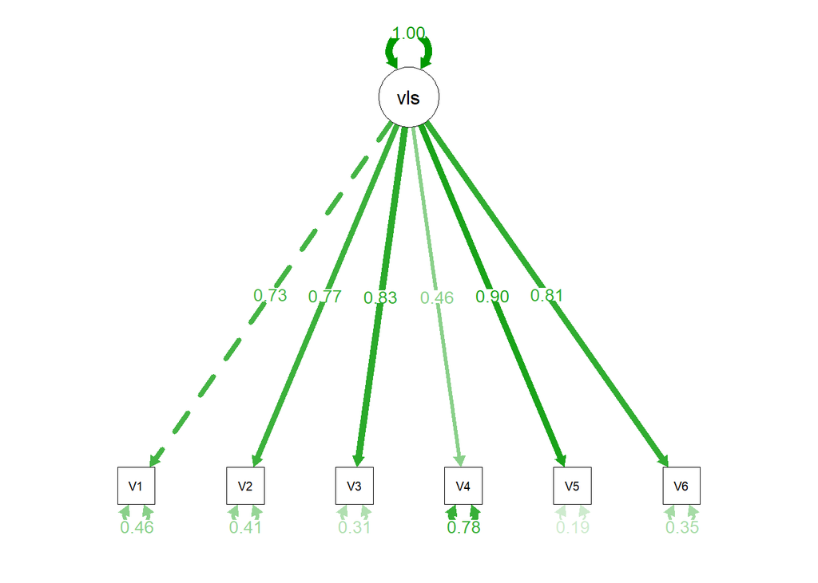

```r
semPlot::semPaths(solution3, "std", edge.label.cex =1, label.cex=1)
```

```r
idx <- lavInspect(solution3, "case.idx")
fscores <- lavPredict(solution3, type="lv")
## loop over factors
for (fs in colnames(fscores)) {
  chem.cfa[idx, fs] <- fscores[ , fs]
}
head(chem.cfa)
```

```
##       GID                 ID semester.x exam1 exam2 exam3 modeE1 modeE2 modeE3
## 1 AAP0049 aap0049@auburn.edu       Su20  75.0    80  62.0    f2f    f2f    f2f
## 2 AAR0036 aar0036@auburn.edu       Su20  89.5    71  72.5 online online online
## 3 AAT0038 aat0038@auburn.edu       Fa20  71.5    82  40.0    f2f    f2f    f2f
## 4 ABM0054 abm0054@auburn.edu       Fa20  91.0    82  86.0   <NA>   <NA>   <NA>
## 5 ABR0032 abr0032@auburn.edu       Su20  63.5    57  57.0 online online online
## 6 ABR0033 abr0033@auburn.edu       Fa20 105.0   114 102.0    f2f    f2f    f2f
##   G1 G2 T1 V1 V2 G3 V3 G4 G5 T2 V4 V5 T3 V6 T4 semester.y ACTHIGHEST SATHIGHEST
## 1 NA NA NA NA NA NA NA NA NA NA NA NA NA NA NA       Su20         32         NA
## 2 NA NA NA NA NA NA NA NA NA NA NA NA NA NA NA       Su20         22          0
## 3  3  5  7  6  3  5  3  4  6  7  5  3  7  4  7       Fa20         26         NA
## 4 NA NA NA NA NA NA NA NA NA NA NA NA NA NA NA       Fa20         28         NA
## 5 NA NA NA NA NA NA NA NA NA NA NA NA NA NA NA       Su20         30         NA
## 6  5  7  2  7  6  7  7  7  4  2  5  7  7  7  3       Fa20         34         NA
##   ACTcalc HS_GPA first_generation gender              race
```

[output cut: 20 more lines]

> for notes on how to produce and interpret semPlots, see : https://www.r-bloggers.com/2018/04/statistics-sunday-using-semplot/ https://cran.r-project.org/web/packages/semPlot/semPlot.pdf http://sachaepskamp.com/documentation/semPlot/semPaths.html

> #CFI: Measures whether the model fits the data better than a more restricted baseline model. Higher is better, with okay fit > .9. Find CFI under User Model vs. Baseline model

> #TLI (Tucker-Lewis index): Similar to CFI, but it penalizes overly complex models (making it more conservative than CFI). Measures whether the model fits the data better than a more restricted baseline model. Higher is better, with okay fit > .9.

> #Find Test statistic, DOF, and P value under Model Test User Model (chi-squared goodness of fit test)

> #RMSEA p value:The RMSEA P-value is the Probability that RMSEA <= .05. If that P-value is greater than 5% you can argue that the RMSEA value does not indicate a model rejection (the RMSEA value doesn’t reject the model if the RMSEA value is between 0 and 0.05). Usually this is useful when the RMSEA value is near the cutoff value of 0.05. If the RMSEA value is not near 0.05 one can typically ignore the confidence limit and the P-value and simply use the actual RMSEA value.

> #std.all are the standardized coefficients

> See this publication and references within on reporting CFA results properly: https://www.researchgate.net/publication/24187223_Reporting_Practices_in_Confirmatory_Factor_Analysis_An_Overview_and_Some_Recommendations

## Incoming Preparation Measures

```r
#Design a data set for PCA analysis. The goal of this is to combine multiple highly correlated variables of incoming preparation.
#subset whole data to include all data points which have ACT and High school GPA measures available. Cumulative GPA when entering class was also available, and included in the data set.

#Note: Most students had ACT scores available, but some did not. When ACT was not available, but SAT was, SAT scores were converted to ACT scores using ACT.org "SAT Concordance Tables".
PCA=chem.cfa[complete.cases(chem.cfa$ACTcalc),]
PCA2=PCA[complete.cases(PCA$HS_GPA),]
#cumulative GPA coming into the class was also at one point included, but this data was not available for many student and the courses taken likely vary extensively. This variable was then not included in the final analysis.
PCA3=PCA2[complete.cases(PCA2$CUM_GPA),]

#Sanity check: ACT score and high school GPA were highly correlated.
cor.test(PCA3$HS_GPA, PCA3$ACTcalc)
```

```
##
##  Pearson's product-moment correlation
##
## data:  PCA3$HS_GPA and PCA3$ACTcalc
## t = 7.5132, df = 209, p-value = 1.658e-12
## alternative hypothesis: true correlation is not equal to 0
## 95 percent confidence interval:
##  0.3477349 0.5612546
## sample estimates:
##       cor
## 0.4611444
```

```r
#Run PCA analysis on ACT score and high school GPA.
perf=princomp(PCA3[28:29], cor=T, scores=TRUE)
#Display results including the PC loadings
summary(perf, loadings=T)
```

```
## Importance of components:
##                           Comp.1    Comp.2
## Standard deviation     1.2087781 0.7340678
## Proportion of Variance 0.7305722 0.2694278
## Cumulative Proportion  0.7305722 1.0000000
##
## Loadings:
##         Comp.1 Comp.2
## ACTcalc  0.707  0.707
## HS_GPA   0.707 -0.707
```

```r
#Plot PCA results
#PCA.pl=autoplot(perf, loadings= T, loadings.label=T)
#PCA.pl

#Add PCA scores as a new column in the PCA dataframe
PCA3=cbind(PCA3, perf$scores)

#NOW MERGE THIS COLUMN TO THE ORIGINAL DATA SET.
PCA4=select(PCA3, GID, Comp.1)
chem.cfa <- merge(chem.cfa,PCA4, by="GID", all=TRUE)
```

```r
#Rename Comp.1 from PCA to "Prep"
rename(chem.cfa, Prep = Comp.1)
```

## Write new data frame with Loaded Latent Variable Values

```r
write.csv(chem.cfa,"CFA_Loadings.csv", row.names = FALSE)

#This data was exported to have a grit, values, and incoming preparation score for each student. That data was then converted to "long" format in excel, and extraneous variables were removed from the data set.
```

# Assess Appropriateness of combining Fall and Summer Performance Measures

```r
chem=read.csv("CHEM_long2.csv")
table(chem$Exam, chem$Format)
```

```
##
##          Face to Face Online
##   Exam 1          126    143
##   Exam 2          127    143
##   Exam 3          108    161
```

```r
ID.unique=as.data.frame(table(chem$ID))

#Does performance differ by semester... before combining the two data sets
anova(lme(Performance~ semester.x, random= ~1|ID, data=chem, na.action=na.omit))
```

```
##             numDF denDF  F-value p-value
## (Intercept)     1   610 3633.748  <.0001
## semester.x      1   302    0.098  0.7544
```

> There is not a statistical difference between the two semesters, and they are therefore combined.

# Test for Outliers, and retrieve statistical measures of data quality for latent variables

```r
#outlier test

outlierTest(lm(Performance~ Format+ Exam + Grit + Anxiety + Values, data=chem, na.action=na.omit))
```

```
## No Studentized residuals with Bonferroni p < 0.05
## Largest |rstudent|:
##     rstudent unadjusted p-value Bonferroni p
## 357 3.380221         0.00077304      0.45378
```

```r
#Calculate mean, SD, SE, CI, skewness and kurtosis for each variable
summarySE(data=chem, measurevar="Grit", groupvars="Format", na.rm=T, conf.interval=0.95)
```

```
##         Format   N        Grit        sd         se         ci
## 1 Face to Face 275  0.05921141 0.8016446 0.04834099 0.09516696
## 2       Online 318 -0.04779955 0.8104231 0.04544627 0.08941443
## 3         <NA>   1 -1.08288177        NA         NA        NaN
```

```r
summarySE(data=chem, measurevar="Values", groupvars="Format", na.rm=T, conf.interval=0.95)
```

```
##         Format   N      Values       sd        se        ci
## 1 Face to Face 272  0.11725938 1.030707 0.0624958 0.1230390
## 2       Online 321 -0.09800103 1.129833 0.0630611 0.1240667
## 3         <NA>   1 -0.43622042       NA        NA       NaN
```

```r
summarySE(data=chem, measurevar="Prep", groupvars="Format", na.rm=T, conf.interval=0.95)
```

```
##         Format   N        Prep       sd         se        ci
## 1 Face to Face 256  0.24143319 1.064182 0.06651140 0.1309816
## 2       Online 286 -0.02303282 1.222924 0.07231303 0.1423354
## 3         <NA>  91 -0.60680782 1.338778 0.14034205 0.2788140
```

```r
f2f=subset(chem, Format == "Face to Face")
online=subset(chem, Format == "Online")

skew(f2f$Grit)
```

```
## [1] -0.9990715
```

```r
kurtosi(f2f$Grit)
```

```
## [1] 0.9624688
```

```r
skew(f2f$Values)
```

```
## [1] -0.8693352
```

```r
kurtosi(f2f$Values)
```

```
## [1] 0.3708223
```

```r
skew(f2f$Prep)
```

```
## [1] 0.1468831
```

```r
kurtosi(f2f$Prep)
```

```
## [1] -0.08083225
```

```r
skew(online$Grit)
```

```
## [1] -0.8928384
```

```r
kurtosi(online$Grit)
```

```
## [1] 0.6604142
```

```r
skew(online$Values)
```

```
## [1] -0.5184901
```

```r
kurtosi(online$Values)
```

```
## [1] -0.5854837
```

```r
skew(online$Prep)
```

```
## [1] -0.5780441
```

```r
kurtosi(online$Prep)
```

```
## [1] -0.09361404
```

# Quantitative Analysis

```r
#read in longitudinal repeated measures data set including all data
chem=read.csv("CHEM_long2.csv")
table(chem$Exam, chem$Format)
```

```
##
##          Face to Face Online
##   Exam 1          126    143
##   Exam 2          127    143
##   Exam 3          108    161
```

```r
ID.unique=as.data.frame(table(chem$ID))


#Set dodge positions for plotting
dodge <- position_dodge(width = 0.6)

#Research Question 1: Were there performance gaps between the two groups?
#Research Question 2: Were there differences in affective measures between the two groups and based on performance?

#run linear model to determine which available variables may affect performance in the course
chem.lm=(lme(Performance~ Format+ Exam + Grit  + Values + Prep, random= ~1|ID/semester.x, data=chem, na.action=na.omit))
anova(chem.lm)
```

```
##             numDF denDF  F-value p-value
## (Intercept)     1   354 5305.224  <.0001
## Format          1   354   54.953  <.0001
## Exam            2   354  168.256  <.0001
## Grit            1   175   39.186  <.0001
## Values          1   175    7.704  0.0061
## Prep            1   175   66.374  <.0001
```

```r
summary(chem.lm)
```

```
## Linear mixed-effects model fit by REML
##  Data: chem
##        AIC      BIC    logLik
##   4374.543 4417.253 -2177.271
##
## Random effects:
##  Formula: ~1 | ID
##         (Intercept)
## StdDev:    7.483447
##
##  Formula: ~1 | semester.x %in% ID
##         (Intercept) Residual
## StdDev:    7.483453 11.64676
##
## Fixed effects: Performance ~ Format + Exam + Grit + Values + Prep
##                  Value Std.Error  DF   t-value p-value
## (Intercept)   79.74673 1.4566128 354  54.74806   0e+00
## FormatOnline  -6.19296 1.6786160 354  -3.68933   3e-04
## ExamExam 2    -5.12851 1.2311367 354  -4.16567   0e+00
## ExamExam 3   -22.01926 1.2406320 354 -17.74842   0e+00
## Grit           4.55901 1.2733931 175   3.58020   4e-04
## Values         3.36251 0.9704281 175   3.46498   7e-04
## Prep           6.78637 0.8329895 175   8.14701   0e+00
##  Correlation:
##              (Intr) FrmtOn ExmEx2 ExmEx3 Grit   Values
## FormatOnline -0.586
## ExamExam 2   -0.427  0.008
## ExamExam 3   -0.356 -0.108  0.495
## Grit          0.000  0.016  0.000 -0.004
## Values       -0.057  0.084  0.001 -0.009 -0.423
## Prep         -0.122  0.092  0.001 -0.011 -0.113  0.086
##
## Standardized Within-Group Residuals:
##         Min          Q1         Med          Q3         Max
## -2.81232461 -0.57348100  0.01666473  0.54313813  2.84033052
##
## Number of Observations: 536
## Number of Groups:
##                 ID semester.x %in% ID
##                179                179
```

```r
chem.lm2=(lme(Performance~ Format+ Exam + Grit  + Values, random=list(~1|ID, ~1|Prep), data=chem, na.action=na.omit))
anova(chem.lm2)
```

```
##             numDF denDF  F-value p-value
## (Intercept)     1   354 3871.479  <.0001
## Format          1   354   48.175  <.0001
## Exam            2   354  167.961  <.0001
## Grit            1   176   28.698  <.0001
## Values          1   176    5.676  0.0183
```

```r
summary(chem.lm2)
```

```
## Linear mixed-effects model fit by REML
##  Data: chem
##      AIC      BIC   logLik
##   4430.7 4469.156 -2206.35
##
## Random effects:
##  Formula: ~1 | ID
##         (Intercept)
## StdDev:    9.225628
##
##  Formula: ~1 | Prep %in% ID
##         (Intercept) Residual
## StdDev:    9.225628 11.65386
##
## Fixed effects: Performance ~ Format + Exam + Grit + Values
##                  Value Std.Error  DF   t-value p-value
## (Intercept)   81.05522  1.605557 354  50.48418  0.0000
## FormatOnline  -7.18224  1.852549 354  -3.87695  0.0001
## ExamExam 2    -5.13403  1.231895 354  -4.16759  0.0000
## ExamExam 3   -21.92920  1.242964 354 -17.64267  0.0000
## Grit           5.73285  1.481026 176   3.87086  0.0002
## Values         2.69605  1.131586 176   2.38254  0.0183
##  Correlation:
##              (Intr) FrmtOn ExmEx2 ExmEx3 Grit
## FormatOnline -0.580
## ExamExam 2   -0.388  0.008
## ExamExam 3   -0.311 -0.119  0.495
## Grit         -0.013  0.025  0.000 -0.005
## Values       -0.045  0.073  0.001 -0.008 -0.418
##
## Standardized Within-Group Residuals:
##         Min          Q1         Med          Q3         Max
## -2.63738251 -0.56818206  0.02217692  0.56686618  2.57020868
##
## Number of Observations: 536
## Number of Groups:
##           ID Prep %in% ID
##          179          179
```

```r
#run linear model examining testing format on performance when correcting for incoming preparation.
anova(lme(Performance~ Format, random=list(~1|ID, ~1|Prep), data=chem, na.action=na.omit))
```

```
##             numDF denDF  F-value p-value
## (Intercept)     1   360 3260.833  <.0001
## Format          1   360   30.236  <.0001
```

```r
anova(lme(Performance~ Format*Exam, random=list(~1|ID, ~1|Prep), data=chem, na.action=na.omit))
```

```
##             numDF denDF  F-value p-value
## (Intercept)     1   356 3264.770  <.0001
## Format          1   356   44.812  <.0001
## Exam            2   356  171.499  <.0001
## Format:Exam     2   356    0.376  0.6871
```

```r
#Single Model Analysis

chem.lm3=(lme(Performance~ Format+ Exam + Grit + Anxiety + Values, random=list(~1|ID, ~1|Prep), data=chem, na.action=na.omit))
anova(chem.lm3)
```

```
##             numDF denDF  F-value p-value
## (Intercept)     1   352 4413.728  <.0001
## Format          1   352   51.004  <.0001
## Exam            2   352  165.919  <.0001
## Grit            1   174   32.781  <.0001
## Anxiety         1   174   26.944  <.0001
## Values          1   174    7.743   0.006
```

```r
summary(chem.lm3)
```

```
## Linear mixed-effects model fit by REML
##  Data: chem
##        AIC      BIC    logLik
##   4382.706 4425.359 -2181.353
##
## Random effects:
##  Formula: ~1 | ID
##         (Intercept)
## StdDev:    8.443411
##
##  Formula: ~1 | Prep %in% ID
##         (Intercept) Residual
## StdDev:    8.443423 11.66618
##
## Fixed effects: Performance ~ Format + Exam + Grit + Anxiety + Values
##                  Value Std.Error  DF   t-value p-value
## (Intercept)   80.36204 1.5476315 352  51.92582  0.0000
## FormatOnline  -5.90671 1.7996049 352  -3.28223  0.0011
## ExamExam 2    -5.05740 1.2366538 352  -4.08958  0.0001
## ExamExam 3   -21.95882 1.2472710 352 -17.60549  0.0000
## Grit           5.01849 1.3900314 174   3.61034  0.0004
## Anxiety       -3.62490 0.6827439 174  -5.30932  0.0000
## Values         2.94443 1.0581380 174   2.78265  0.0060
##  Correlation:
##              (Intr) FrmtOn ExmEx2 ExmEx3 Grit   Anxity
## FormatOnline -0.588
## ExamExam 2   -0.404  0.008
## ExamExam 3   -0.328 -0.115  0.495
## Grit         -0.007  0.013  0.000 -0.004
## Anxiety       0.091 -0.150 -0.001  0.015  0.095
## Values       -0.048  0.079  0.001 -0.009 -0.420 -0.044
##
## Standardized Within-Group Residuals:
##          Min           Q1          Med           Q3          Max
## -2.479799986 -0.555650921 -0.004121443  0.558264459  2.568386122
##
## Number of Observations: 533
## Number of Groups:
##           ID Prep %in% ID
##          178          178
```

> Class form, exam number, grit, values, and incoming preparation all significantly effected performance in the course when taking “ID” into account as a repeated measure. Because incoming prepartion has a clear affect on performance, and our focus is on how the two testing formats effect performance, a second linear model was performed examining the effect of testing format on performance when incominging preparation is taken into account. Even when incoming preparation is taken into account, testing format significantly effected class performance.

# Visualization of Performance Data by Exam and Testing Modality

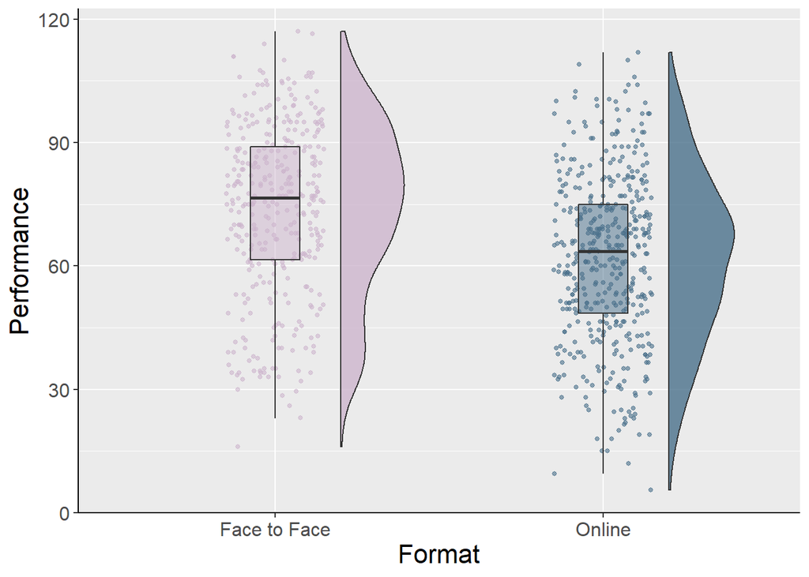

```r
#make a data frame that includes all student data for which we have testing format designations.
format= chem %>% drop_na(Format)

#design a raincloud theme for plotting performance data.
raincloud_theme = theme(
text = element_text(size = 10),
axis.title.x = element_text(size = 16),
axis.title.y = element_text(size = 16),
axis.text = element_text(size = 12),
#axis.text.x = element_text(angle = 45, vjust = 0.5),
legend.title=element_text(size=16),
legend.text=element_text(size=16),
legend.position = "right",
plot.title = element_text(lineheight=.8, face="bold", size = 16),
panel.border = element_blank(),
#panel.grid.minor = element_blank(),
#panel.grid.major = element_blank(),
axis.line.x = element_line(colour = 'black', size=0.5, linetype='solid'),
axis.line.y = element_line(colour = 'black', size=0.5, linetype='solid'))

#Set calculations for upper and lower boundaries
lb <- function(x) mean(x) - sd(x)
ub <- function(x) mean(x) + sd(x)

#use ddply package to calculate means, median, lower and upper boundaries for Performance of students, for each format.
sumld<- ddply(format, ~Format, summarise, mean = mean(Performance), median = median(Performance), lower = lb(Performance), upper = ub(Performance))


#Plot performance by format. Raincloud plots were designed to show a point distribution of data with an overlaying boxplot alongside a density plot distribution.

rain2=ggplot(data = format, aes(y = Performance, x = Format, fill = Format)) +
geom_flat_violin(position = position_nudge(x = .2, y = 0), alpha = .8, width=.4) +
geom_point(aes(y = Performance, color = Format), position = position_jitter(width = .15), size = 1, alpha = 0.6) +
geom_boxplot(width = .15, guides = FALSE, outlier.shape = NA, alpha = 0.5) +
expand_limits(x = 2) +
guides(fill = FALSE) +
guides(color = FALSE) +
  scale_fill_manual(values = c("thistle3", "skyblue4")) +
  scale_color_manual(values = c("thistle3", "skyblue4")) +
       theme(strip.text.x = element_text(size = 16, face = "bold"))+
raincloud_theme
rain2
```

```r
ggsave(rain2, file="rain_perf_average.png", height=8, width=4, dpi = 300)
```

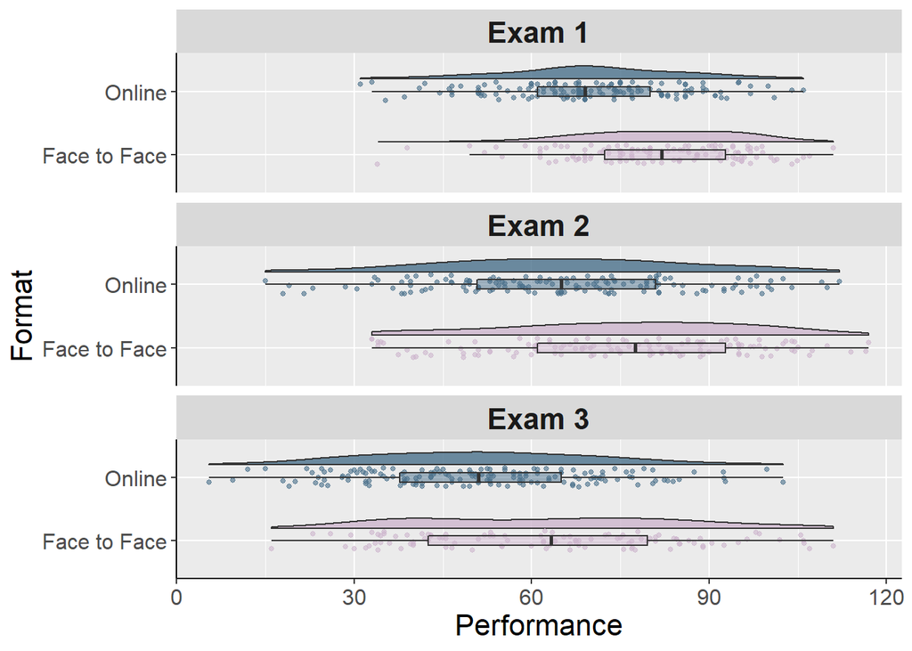

```r
#Multipanel plot by exam number

rain=ggplot(data = format, aes(y = Performance, x = Format, fill = Format)) +
geom_flat_violin(position = position_nudge(x = .2, y = 0), alpha = .8, width=.4) +
geom_point(aes(y = Performance, color = Format), position = position_jitter(width = .15), size = 1, alpha = 0.6) +
geom_boxplot(width = .15, guides = FALSE, outlier.shape = NA, alpha = 0.5) +
expand_limits(x = 2) +
guides(fill = FALSE) +
guides(color = FALSE) +
  scale_fill_manual(values = c("thistle3", "skyblue4")) +
  scale_color_manual(values = c("thistle3", "skyblue4")) +
       theme(strip.text.x = element_text(size = 16, face = "bold"))+
raincloud_theme +
  coord_flip()+
  facet_wrap(~Exam,   dir = "v")
rain
```

```r
ggsave(rain, file="rain_perf.png", height=8, width=8, dpi = 300)
```

# Affect Measure Data Frame Manipulation

```r
#affective measures were collected at one time. To avoid pseudoreplication, the values were subsetted to occur only one time (exam 1). In other words, the students took the survey one time and a measure of perceived value and intrinsic goal orientation was calculated as a single value, then applied to each student at each of the three time points. One time point was chosen for analysis to not inflate the sample size by using the same value at three time points.

aff=subset(chem, Exam== "Exam 1")
#Select columns containing measured variables of interest.
aff=chem[, c(2,6,22,24:25)]

df_melted = melt(aff, id.vars=c("ID", "Format"), variable.name="Construct", value.name="Value")
df_melted=df_melted[complete.cases(df_melted),]
```

# Analysis of Intrinsic Goal Orientation, Perceived Value of Chemistry, and Incoming Preparation

```r
anova(lme(Grit~ Format, data=aff, random=~1|ID, na.action=na.omit))
```

```
##             numDF denDF    F-value p-value
## (Intercept)     1   394 0.00000000  1.0000
## Format          1   394 0.04149077  0.8387
```

```r
anova(lme(Prep~ Format, data=aff, random=~1|ID, na.action=na.omit))
```

```
##             numDF denDF   F-value p-value
## (Intercept)     1   360 1.4034911  0.2369
## Format          1   360 0.5223772  0.4703
```

```r
anova(lme(Values~ Format, data=aff, random=~1|ID, na.action=na.omit))
```

```
##             numDF denDF  F-value p-value
## (Intercept)     1   394 0.000833  0.9770
## Format          1   394 4.392502  0.0367
```

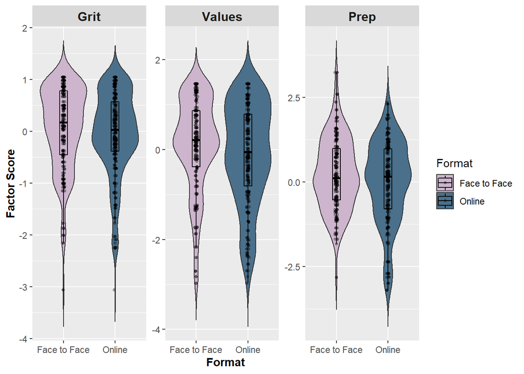

```r
p1=ggplot(df_melted, aes(x = Format, y = Value, fill=Format)) +
 geom_violin(trim=F, position= dodge, scale="width") +
  scale_fill_manual(values = c("thistle3", "skyblue4")) +
  geom_boxplot(width=0.15, position= dodge, outlier.shape = NA, color="black") +
  geom_point(position=position_jitterdodge(jitter.width = 0.05, dodge.width = 0.6), size=1, alpha=0.3) +
  ylab("Factor Score")+
  theme(strip.text.x = element_text(size = 12, face = "bold"),
        axis.title = element_text(size=11, face="bold")) +
  facet_wrap(~Construct, scales = "free")

ggsave(p1, file="Affect.png", width=8, height=4, dpi=300)
p1
```

```r
cor.test(format$Values, format$Performance)
```

```
##
##  Pearson's product-moment correlation
##
## data:  format$Values and format$Performance
## t = 5.9093, df = 591, p-value = 5.807e-09
## alternative hypothesis: true correlation is not equal to 0
## 95 percent confidence interval:
##  0.1586991 0.3108019
## sample estimates:
##       cor
## 0.2361968
```

```r
cor.test(format$Grit, format$Performance)
```

```
##
##  Pearson's product-moment correlation
##
## data:  format$Grit and format$Performance
## t = 7.0698, df = 591, p-value = 4.395e-12
## alternative hypothesis: true correlation is not equal to 0
## 95 percent confidence interval:
##  0.2032986 0.3518485
## sample estimates:
##       cor
## 0.2792435
```

```r
cor.test(format$Prep, format$Performance)
```

```
##
##  Pearson's product-moment correlation
##
## data:  format$Prep and format$Performance
## t = 9.8261, df = 540, p-value < 2.2e-16
## alternative hypothesis: true correlation is not equal to 0
## 95 percent confidence interval:
##  0.3155895 0.4586374
## sample estimates:
##       cor
## 0.3894595
```

```r
cor.val=ggplot() +
  geom_point(data=format, aes(x=Performance, y=Values, color=Format)) +
  scale_color_manual(values = c("thistle3", "skyblue4")) +
  geom_smooth(data=format, aes(x=Performance, y = Values), method=lm, color="black") +
  theme(legend.position="none")

ggsave(cor.val, file="cor.val.png", height=2, width=3, dpi = 300)
cor.grit=ggplot() +
  geom_point(data=format, aes(x=Performance, y=Grit, color=Format)) +
  scale_color_manual(values = c("thistle3", "skyblue4")) +
  geom_smooth(data=format, aes(x=Performance, y = Grit), method=lm, color="black") +
    theme(legend.position="none")


ggsave(cor.grit, file="cor.grit.png", height=2, width=3, dpi = 300)
cor.prep=ggplot() +
  geom_point(data=format, aes(x=Performance, y=Prep, color=Format)) +
  scale_color_manual(values = c("thistle3", "skyblue4")) +
  geom_smooth(data=format, aes(x=Performance, y = Prep), method=lm, color="black") +
    theme(legend.position="none")


ggsave(cor.prep, file="cor.prep.png", height=2, width=3, dpi = 300)
```

# Engagement by Performance Outcomes Analysis

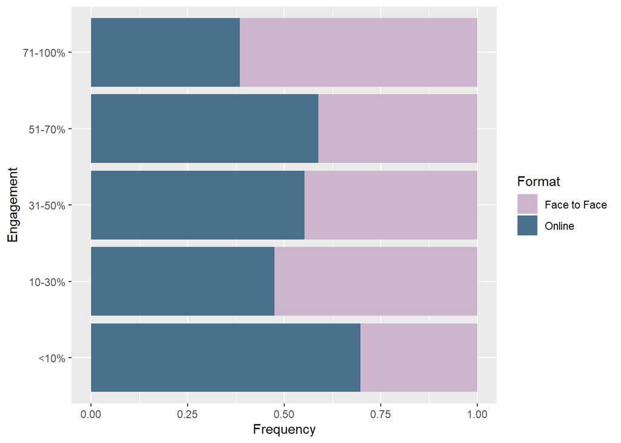

```r
#Upload long data including additional variables for visual analysis only
sec_var=read.csv("CHEM_long.csv")

#histogram of engagement between formats

eng= sec_var %>% drop_na(engagement)
eng= eng %>% drop_na(Format)

eng.pl=ggplot(eng, aes(x=engagement, fill=Format)) +
  geom_bar(position="fill") +
    scale_fill_manual(values = c("thistle3", "skyblue4")) +
  ylab("Frequency")+
  coord_flip() +
  xlab("Engagement")

eng.pl
```

```r
ggsave(eng.pl, file="eng.png", height=6, width=4, dpi = 300)

eng.lm=(lme(Performance~ engagement*Format, random= ~1|ID, data=eng, na.action=na.omit))
anova(eng.lm)
```

```
##                   numDF denDF  F-value p-value
## (Intercept)           1   378 4001.670  <.0001
## engagement            4   187    6.558  0.0001
## Format                1   378   35.090  <.0001
## engagement:Format     4   378    0.992  0.4120
```

```r
eng1=subset(eng, engagement== "<10%")
eng2=subset(eng, engagement== "10-30%")
eng3=subset(eng, engagement== "31-50%")
eng4=subset(eng, engagement== "51-70%")
eng5=subset(eng, engagement== "71-100%")

anova(lme(Performance~ Format, random= ~1|ID, data=eng1, na.action=na.omit))
```

```
##             numDF denDF  F-value p-value
## (Intercept)     1    43 446.0164  <.0001
## Format          1    43   2.0028  0.1642
```

```r
anova(lme(Performance~ Format, random= ~1|ID, data=eng2, na.action=na.omit))
```

```
##             numDF denDF  F-value p-value
## (Intercept)     1    66 493.9145  <.0001
## Format          1    66   6.6867  0.0119
```

```r
anova(lme(Performance~ Format, random= ~1|ID, data=eng3, na.action=na.omit))
```

```
##             numDF denDF  F-value p-value
## (Intercept)     1    87 986.8864  <.0001
## Format          1    87   1.5446  0.2173
```

```r
anova(lme(Performance~ Format, random= ~1|ID, data=eng4, na.action=na.omit))
```

```
##             numDF denDF   F-value p-value
## (Intercept)     1   119 1342.5334  <.0001
## Format          1   119   20.0287  <.0001
```

```r
anova(lme(Performance~ Format, random= ~1|ID, data=eng5, na.action=na.omit))
```

```
##             numDF denDF  F-value p-value
## (Intercept)     1    63 801.8423  <.0001
## Format          1    63   8.0149  0.0062
```

```r
eng.pl2=ggplot(data=eng, aes(x=engagement, y=Performance, group=Format, color=Format)) +
  geom_smooth(stat='summary', fun.y='mean') +
  geom_point(stat='summary', fun.y='mean') +
  scale_color_manual(values = c("thistle3", "skyblue4")) +
  xlab("Engagement")
ggsave(eng.pl2, file="eng2.png", height=4, width=6, dpi = 300)
```

```
## No summary function supplied, defaulting to `mean_se()`
## No summary function supplied, defaulting to `mean_se()`
```

```r
eng.pl2
```

```
## No summary function supplied, defaulting to `mean_se()`
## No summary function supplied, defaulting to `mean_se()`
```

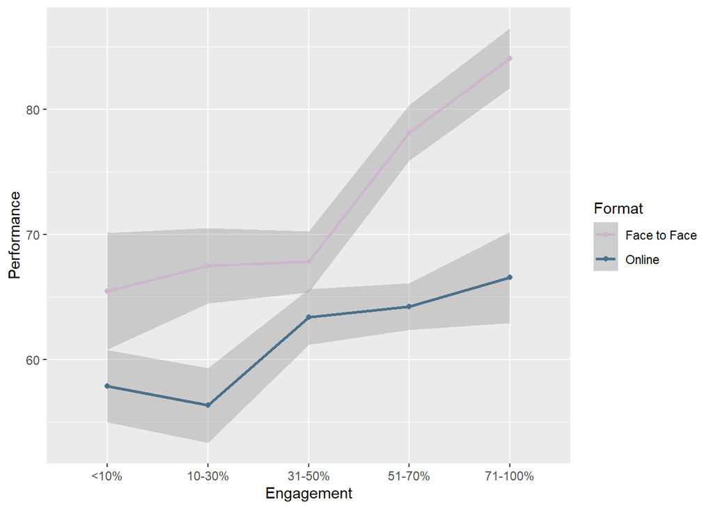

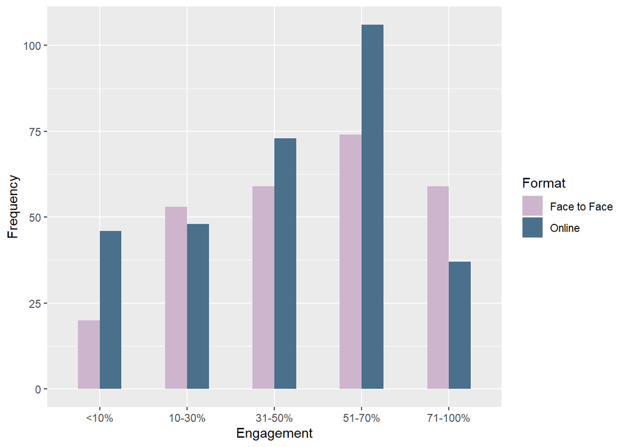

```r
his=ggplot(eng, aes(x=engagement, fill=Format)) +
  geom_bar(position="dodge", width=0.5) +
    scale_fill_manual(values = c("thistle3", "skyblue4")) +
  ylab("Frequency")+
  xlab("Engagement")

his
```

```r
ggsave(his, file="his.eng.png", height=2, width=6, dpi = 300)
```

# Descriptive Statistics for Demographics Analysis

```r
demo.o=subset(chem, Format=="Online")
demo.f=subset(chem, Format == "Face to Face")



tabyl(chem, gender, Format) %>%
  adorn_percentages("col") %>%
  adorn_pct_formatting(digits = 1)
```

```
##  gender Face to Face Online   NA_
##       F        65.7%  70.9% 56.6%
##       M        34.3%  29.1% 43.4%
```

```r
tabyl(chem, class, Format) %>%
  adorn_percentages("col") %>%
  adorn_pct_formatting(digits = 1)
```

```
##  class Face to Face Online   NA_
##     FR        79.8%  86.1% 78.8%
##     JR         5.3%   5.8%  5.3%
##     P1         0.8%   0.7%  0.0%
##    PHD         0.8%   0.0%  0.0%
##     SO        11.4%   5.6% 15.9%
##     SR         1.9%   1.8%  0.0%
```

```r
tabyl(chem, race, Format) %>%
  adorn_percentages("col") %>%
  adorn_pct_formatting(digits = 1)
```

```
##                                 race Face to Face Online   NA_
##                                Asian         3.6%   3.8%  2.7%
##            Black or African American         0.8%   3.4% 10.6%
##                    Caucasian / White        86.7%  75.2% 73.5%
##                             Hispanic         4.2%   4.7%  5.3%
##  Native Hawaiian or Pacific Islander         0.8%   0.0%  0.0%
##                   Non-Resident Alien         0.0%   5.4%  2.7%
##                    Two or more races         3.9%   7.6%  5.3%
```

```r
tabyl(chem, first_generation, Format) %>%
  adorn_percentages("col") %>%
  adorn_pct_formatting(digits = 1)
```

```
##  first_generation Face to Face Online   NA_
##                           4.4%  12.5%  8.0%
##                 N        81.4%  73.4% 76.1%
##                 Y        14.1%  14.1% 15.9%
```